# Rejection sampling: Non-conjugate Binomial example

Patrick Graham

7 September 2018

[output not shown]

[output not shown]

[output not shown]

[output not shown]

[output not shown]

```
## Working directory is C:/Users/Patrick Graham/Documents/Patrick/Stat314-2018/code/src
```

## Illustration of the likelihood as a function of the model parameter.

Before looking at rejection sampling we illustrate the idea of the likelihood as function of the model parameter. Consider a study comprising 6 Binomial experiments each with N=10 trial The data is:

```r
Y <- c(6,7,5,5,4,8)
N <- rep(10,length(Y) )
```

We compute some summaries typically involved in Bayesian calculations.

```r
NmY <- N-Y

sumY <- sum(Y)
sumNmY <- sum(N-Y)
sumY
```

```
## [1] 35
```

```r
sumNmY
```

```
## [1] 25
```

Now we set-up a function to compute the log-likelihood. When doing numerical work with likelihoods it usually best to work on the (natural) log scale.

```r
loglike_binom <- function(theta,Y,N)  {
  logl <- dbinom(Y,N,prob=theta,log=TRUE)
  return(sum(logl))
}

##Evaluate at a few points
loglike_binom(theta=0.4,Y=Y,N=N)
```

```
## [1] -14.49359
```

```r
loglike_binom(theta=0.1,Y=Y,N=N)
```

```
## [1] -52.87726
```

```r
loglike_binom(theta=0.8,Y=Y,N=N)
```

```
## [1] -17.69874
```

```r
###Plot the log-likelihood for a range of sucesss probabilities

testtheta <- seq(from=0.01,to=0.99,by=0.01) #range of theta's to test

##set up structure to store log-likelihoods for plotting
loglstore <- vector(mode="numeric",length=length(testtheta))

##Loop over theta values and compute the corresponding log-likelihood

for (i in 1:length(testtheta)) {
  loglstore[i] <- loglike_binom(theta=testtheta[i],Y=Y,N=N)
}
loglstore
```

```
##  [1] -131.08499 -107.07865  -93.14378  -83.33398  -75.78573  -69.66903
##  [7]  -64.54114  -60.13782  -56.28864  -52.87726  -49.82074  -47.05783
## [13]  -44.54205  -42.23729  -40.11495  -38.15196  -36.32950  -34.63199
## [19]  -33.04639  -31.56169  -30.16850  -28.85878  -27.62555  -26.46277
## [25]  -25.36513  -24.32798  -23.34721  -22.41917  -21.54063  -20.70869
## [31]  -19.92077  -19.17453  -18.46790  -17.79900  -17.16612  -16.56774
## [37]  -16.00249  -15.46911  -14.96648  -14.49359  -14.04953  -13.63347
## [43]  -13.24470  -12.88255  -12.54647  -12.23593  -11.95052  -11.68986
## [49]  -11.45363  -11.24160  -11.05358  -10.88943  -10.74908  -10.63251
## [55]  -10.53976  -10.47093  -10.42619  -10.40574  -10.40987  -10.43894
## [61]  -10.49336  -10.57363  -10.68032  -10.81410  -10.97573  -11.16605
## [67]  -11.38605  -11.63682  -11.91958  -12.23572  -12.58679  -12.97456
## [73]  -13.40098  -13.86829  -14.37900  -14.93597  -15.54244  -16.20211
## [79]  -16.91925  -17.69874  -18.54629  -19.46852  -20.47323  -21.56968
## [85]  -22.76893  -24.08440  -25.53247  -27.13353  -28.91333  -30.90502
## [91]  -33.15229  -35.71434  -38.67425  -42.15368  -46.34134  -51.55344
## [97]  -58.38279  -68.16044  -85.13379
```

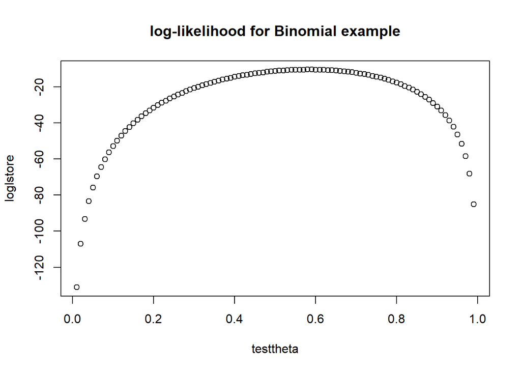

```r
###Plot the log-likelihood

plot(testtheta,loglstore,main="log-likelihood for Binomial example")
```

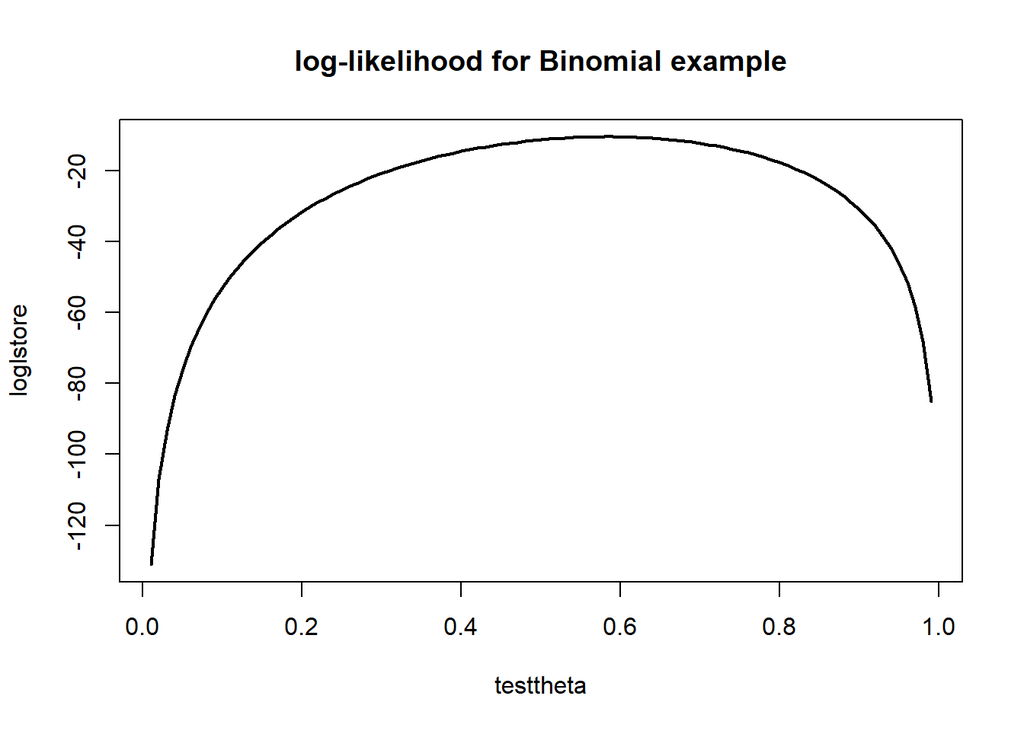

```r
##clearer if we plot a line? A continuous function after all

plot(testtheta,loglstore,type="l",lwd=2.0,main="log-likelihood for Binomial example")
```

## Rejection sampler for a non-conjugte Binomial problem

$$\begin{aligned}
Y_{i} & \stackrel{\mathrm{indep}}{\sim} \mathrm{Binomial}(10,\theta) \nonumber \\
\mathrm{logit}(\theta) & \sim \mathrm{Normal}(\mu,\sigma^{2}) \\
p(\theta|\mathbf{Y},N) & \propto \prod_{i}\mathrm{Binomial}(Y_{i}|10,\theta) \times \mathrm{logitN}(\theta|\mu,\sigma^{2})
\end{aligned}$$
To get familiar with the logit-normal prior we plot this density for a few different parameter combinations.

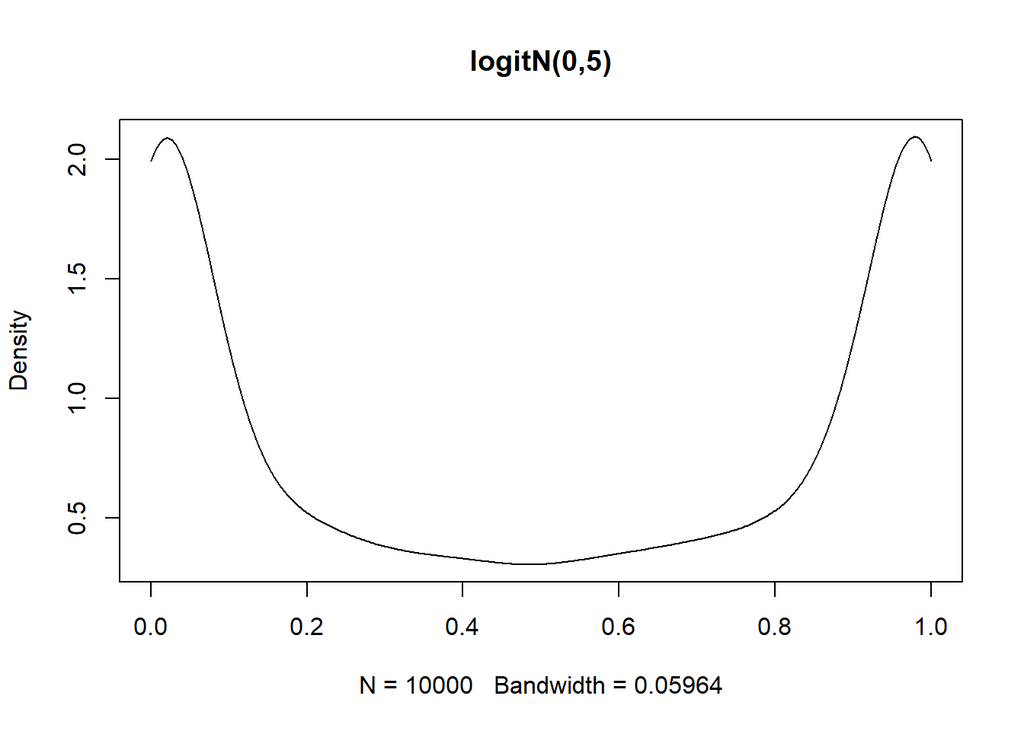

```r
##first define a function to simulate from the logit-normal
rlogitnormal <- function(n,mu,sigma) {
  require(arm)
  l <- rnorm(n=n,mean=mu,sd=sigma)
  theta <- invlogit(l)
  return(theta)
}

##specify parameters of the prior
mu_prior <- logit(0.5)
sigma_prior <- 5

###Plot the prior
testtheta <- rlogitnormal(n=10000,mu=mu_prior,sigma=sigma_prior)
density_prior <- density(testtheta,from=0,to=1)
plot(density_prior,main=paste("logitN(",round(mu_prior,2),",",sigma_prior,")",sep=""))
```

```r
summary(testtheta)
```

```
##    Min. 1st Qu.  Median    Mean 3rd Qu.    Max.
## 0.00000 0.03281 0.51585 0.50217 0.96748 1.00000
```

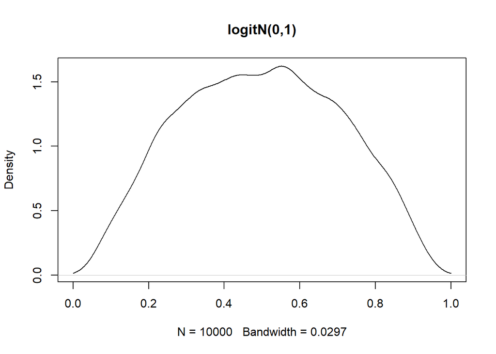

```r
###Try another set of parameters
mu_prior <- logit(0.5)
sigma_prior <- 1

###Plot the prior
testtheta <- rlogitnormal(n=10000,mu=mu_prior,sigma=sigma_prior)
density_prior <- density(testtheta,from=0,to=1)
plot(density_prior,main=paste("logitN(",round(mu_prior,2),",",sigma_prior,")",sep=""))
```

```r
summary(testtheta)
```

```
##    Min. 1st Qu.  Median    Mean 3rd Qu.    Max.
## 0.03173 0.33327 0.49800 0.49731 0.66036 0.98840
```

### Rejection sampling.

If our approximation is the prior, $r(\theta)$ is the likelihood. Hence we accept draws with probability Likelihood/M where M is the value of the likelihood evaluated at the MLE. It is easier to work on the log-scale and so find $\log(M)$ by computing the log-likelihood with $\theta$ set to the MLE, which is $\hat{\theta}=\sum_{i}Y_{i} /\sum_{i}N_{i}.$

```r
logM <- loglike_binom(theta=(sum(Y)/sum(N)),Y=Y,N=N)

##specify the prior
mu_prior <- logit(0.5)
sigma_prior <- 5

##set-up the rejection sampling loop
simnum <- 2000 #desired simulation sample size
storetheta <- vector(mode="numeric",length=simnum)
accepted <- 0
rejected <- 0

while(accepted < simnum) {
  theta_prop <- rlogitnormal(n=1,mu=mu_prior,sigma=sigma_prior)
  ###Evaluate the likelihood at this proposal
  llike_prop <- loglike_binom(Y=Y,N=N,theta=theta_prop)


  U <- runif(1)
  if (log(U) < llike_prop - logM) {
    accepted <- accepted + 1
    storetheta[accepted] <- theta_prop
  } else {
    rejected <- rejected + 1
  }
}
summary(storetheta)
```

```
##    Min. 1st Qu.  Median    Mean 3rd Qu.    Max.
##  0.3771  0.5416  0.5843  0.5835  0.6275  0.7553
```

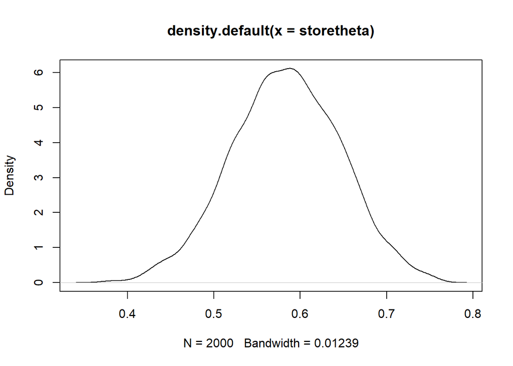

```r
plot(density(storetheta))
```

```r
accepted
```

```
## [1] 2000
```

```r
rejected
```

```
## [1] 35058
```

```r
acceptance_rate <- accepted/(accepted+rejected)
acceptance_rate
```

```
## [1] 0.05396945
```

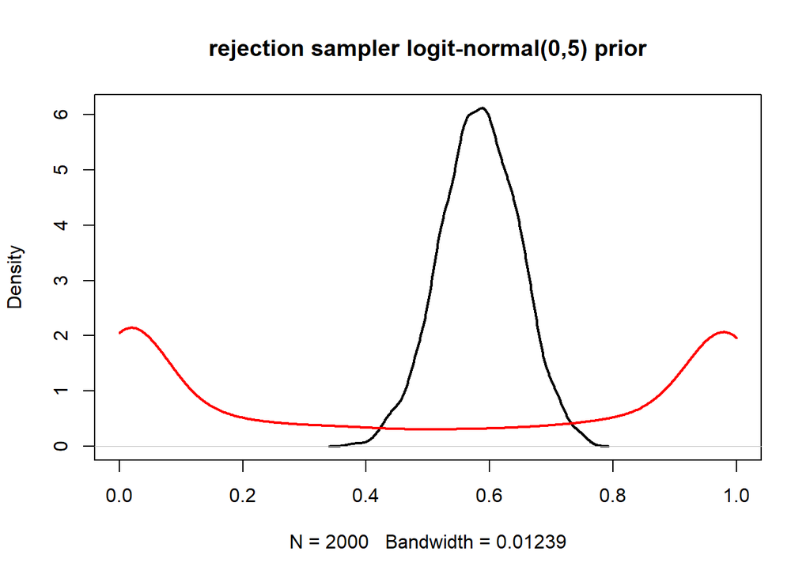

```r
###plot posterior density plot with prior superimposed
#- to illustrate ideas around quality of
##approximatin density
testtheta <- rlogitnormal(n=10000,mu=mu_prior,sigma=sigma_prior)
density_prior <- density(testtheta,from=0,to=1)
plot(density(storetheta),
     main="rejection sampler logit-normal(0,5) prior",lwd=2,xlim=c(0,1))
lines(density_prior,lwd=2,col="red")
```

Now we repeat all this with an alternative alternative prior, which is less diffuse and again use the prior as the approximating density.

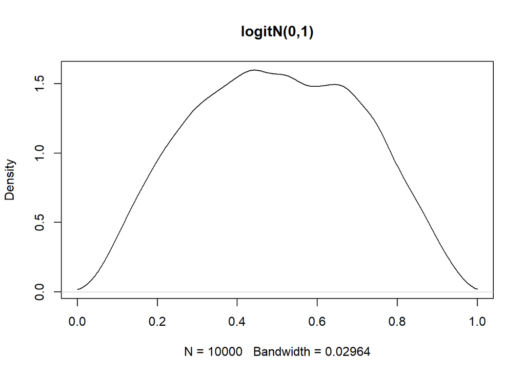

```r
##specify parameters of the prior
mu_prior <- logit(0.5)  #logit(0.5) =0
sigma_prior <- 1

###Plot the prior
testtheta <- rlogitnormal(n=10000,mu=mu_prior,sigma=sigma_prior)
density_prior <- density(testtheta,from=0,to=1)
plot(density_prior,main=paste("logitN(",round(mu_prior,2),",",sigma_prior,")",sep=""))
```

```r
summary(testtheta)
```

```
##    Min. 1st Qu.  Median    Mean 3rd Qu.    Max.
## 0.02314 0.33660 0.49922 0.49927 0.66422 0.97089
```

```r
##Find log(M) - log of maximum value of the ratio of the unnormalized posterior density (q) to the approximating density
logM <- loglike_binom(theta=(sum(Y)/sum(N)),Y=Y,N=N) ##working with the
#unnormalized density
simnum <- 2000 #desired simulation sample size
storetheta <- vector(mode="numeric",length=simnum)
accepted <- 0
rejected <- 0

while(accepted < simnum) {
  theta_prop <- rlogitnormal(n=1,mu=mu_prior,sigma=sigma_prior)
  ###Evaluate the likelihood at this proposal
  llike_prop <- loglike_binom(Y=Y,N=N,theta=theta_prop)


  U <- runif(1)
  if (log(U) < llike_prop - logM) {
    accepted <- accepted + 1
    storetheta[accepted] <- theta_prop
  } else {
    rejected <- rejected + 1
  }
}
summary(storetheta)
```

```
##    Min. 1st Qu.  Median    Mean 3rd Qu.    Max.
##  0.3704  0.5366  0.5781  0.5768  0.6196  0.7594
```

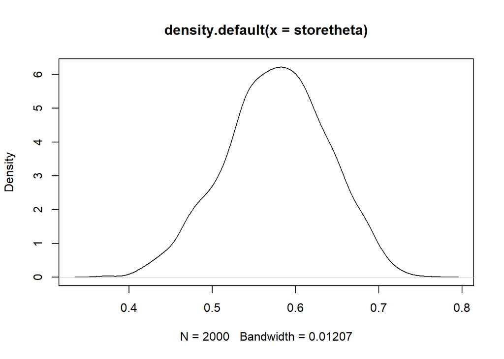

```r
plot(density(storetheta))
```

```r
accepted
```

```
## [1] 2000
```

```r
rejected
```

```
## [1] 5949
```

```r
acceptance_rate <- accepted/(accepted+rejected)
acceptance_rate
```

```
## [1] 0.251604
```

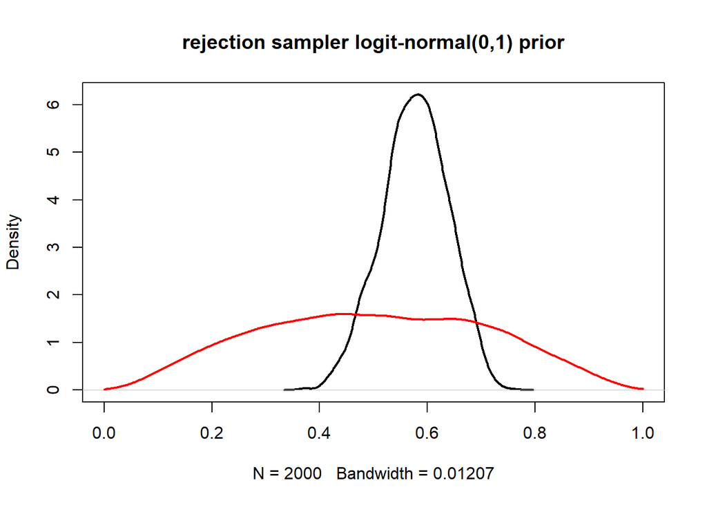

```r
###plot posterior density plot with prior superimposed
#- to illustrate ideas around quality of
##approximatin density
plot(density(storetheta),
     main="rejection sampler logit-normal(0,1) prior",lwd=2,xlim=c(0,1))
lines(density_prior,lwd=2,col="red")
```

### Using a Beta approximation to the posterior as the approximating density.

We consider again the diffuse logit-normal prior.

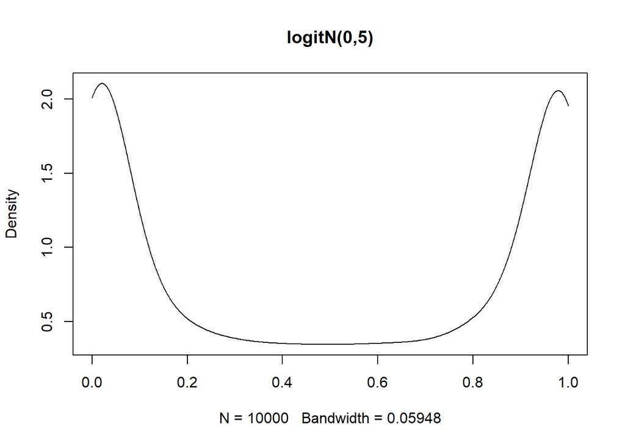

```r
##Go back to the original prior
mu_prior <- logit(0.5)
sigma_prior <- 5
##Re-draw the logit-normal  sample from the prior
testtheta <- rlogitnormal(n=10000,mu=mu_prior,sigma=sigma_prior)
density_prior <- density(testtheta)
plot(density(testtheta,from=0,to=1),main=paste("logitN(",round(mu_prior,2),",",sigma_prior,")",sep=""))
```

```r
summary(testtheta)
```

```
##    Min. 1st Qu.  Median    Mean 3rd Qu.    Max.
## 0.00000 0.03154 0.49078 0.49650 0.96405 1.00000
```

We can approximate the logit-normal prior with a Beta distribution with the same mean and variance.

```r
mean_theta <- mean(testtheta)
var_theta <- (sd(testtheta))^2
mean_theta
```

```
## [1] 0.4965012
```

```r
var_theta
```

```
## [1] 0.1738804
```

```r
a <- (mean_theta^2*(1-mean_theta) - var_theta*mean_theta)/var_theta
b <- a*(1-mean_theta)/mean_theta
a
```

```
## [1] 0.2173184
```

```r
b
```

```
## [1] 0.2203812
```

```r
###plot the beta density with these values
##could  do  exactly using dbeta but will simulate

apprxtheta <- rbeta(10000,a,b)
summary(apprxtheta)
```

```
##    Min. 1st Qu.  Median    Mean 3rd Qu.    Max.
## 0.00000 0.03064 0.48766 0.49498 0.96309 1.00000
```

```r
mean(apprxtheta)
```

```
## [1] 0.4949783
```

```r
(sd(apprxtheta))^2
```

```
## [1] 0.1734506
```

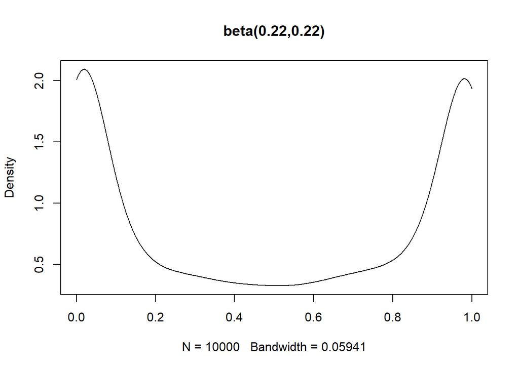

```r
density_prior_beta <- density(apprxtheta,from=0,to=1)

plot(density_prior_beta,main=paste("beta(",round(a,2),",",round(b,2),")",sep=""))
```

We can construct a beta approximation to the posterior using standard the standard conjugate udating formulae for the binomial-beta model.

```r
apos <- a + sumY #sum_i Y_i
bpos <- b + sumNmY  #sum_i (N_i-Y_i)

#check approximate posterior mean
apos/(apos+bpos)
```

```
## [1] 0.5827045
```

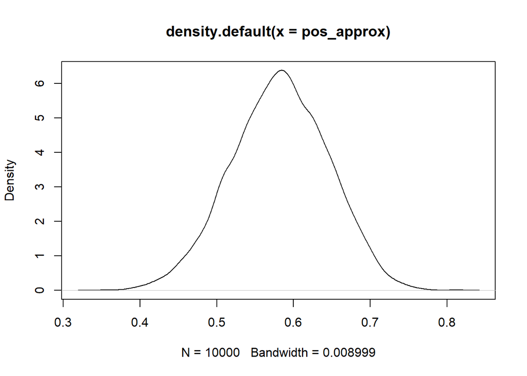

```r
pos_approx <- rbeta(10000,apos,bpos)
density_pos_betaapprx <- density(pos_approx)
plot(density(pos_approx))
```

We Need to find the maximum of $\mathrm{Binomial}(Y|N,\theta)\mathrm{logit}(\theta|mu,\sigma) / \mathrm{beta}(\theta|\mathrm{apos},\mathrm{bpos})$ on a log scale. We take a simple brute force approach by evaluating $\log r(\theta)$ over the parameter space which is just $(0,1).$

```r
###set up a function for logr()

logr <- function(phi) {
  rtheta <- (sum(Y)*log(phi) + sum(N-Y)*log(1-phi) +
               dlogitnorm(q=phi,mu=mu_prior,s=sigma_prior,log=TRUE))
              - dbeta(phi,shape1=apos,shape2=bpos,log=TRUE)
  return(rtheta)}

#evaluate logr over the (0,1) interval

theta_test <- seq(from=0.001,to=0.999,by=0.0001)
logrtheta<- logr(phi=theta_test)
summary(logrtheta)
```

```
##    Min. 1st Qu.  Median    Mean 3rd Qu.    Max.
## -238.37  -66.69  -50.47  -60.26  -43.79  -41.87
```

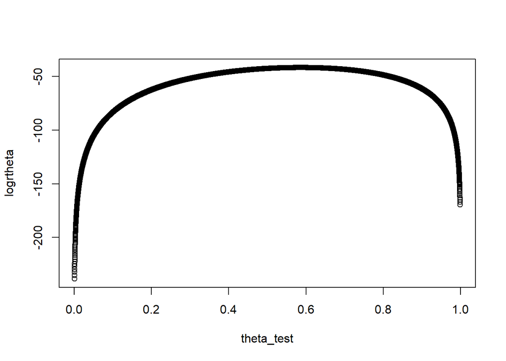

```r
plot(theta_test,logrtheta)
```

```r
which.max(logrtheta)  ###This identifies the position in the logrtheta vector
```

```
## [1] 5851
```

```r
                      ###at which the maximum value of logrtheta is                           ##### found

theta_maxr <- theta_test[which.max(logrtheta)]     #Value of theta which maximises logrtheta
logM2 <- logrtheta[which.max(logrtheta)]
theta_maxr
```

```
## [1] 0.586
```

```r
logM2
```

```
## [1] -41.86694
```

```r
##check logM2 should equal the value of logr evaluated at theta_maxr
logr(theta_maxr)
```

```
## [1] -41.86694
```

Now we know $\log M$ we can set up the rejection sampler.

```r
 ###Set up the rejection sampler
simnum <- 2000 #desired simulation sample size
storetheta2 <- vector(mode="numeric",length=simnum)
accepted2 <- 0
rejected2 <- 0

while(accepted2 < simnum) {
  theta_prop <- rbeta(n=1,shape=apos,shape2=bpos)
  ###Evaluate the log - importance ratio at this proposal
  logr_prop <- logr(phi=theta_prop)

  U <- runif(1)
  if (log(U) < logr_prop - logM2) {
    accepted2 <- accepted2 + 1
    storetheta2[accepted2] <- theta_prop
  } else {
    rejected2 <- rejected2 + 1
  }
}
summary(storetheta2)
```

```
##    Min. 1st Qu.  Median    Mean 3rd Qu.    Max.
##  0.4185  0.5546  0.5846  0.5843  0.6143  0.7632
```

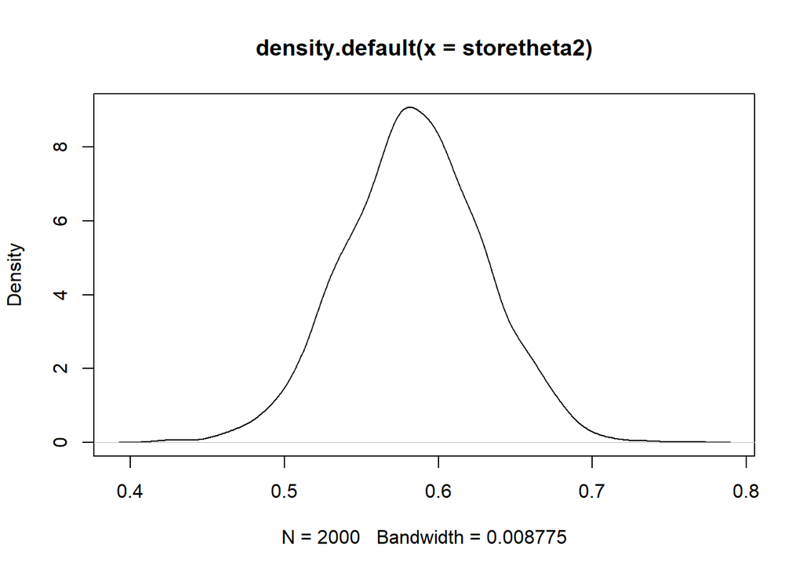

```r
plot(density(storetheta2))
```

```r
accepted2
```

```
## [1] 2000
```

```r
rejected2
```

```
## [1] 779
```

```r
acceptance_rate2 <- accepted2/(accepted2 + rejected2)
acceptance_rate2
```

```
## [1] 0.7196833
```

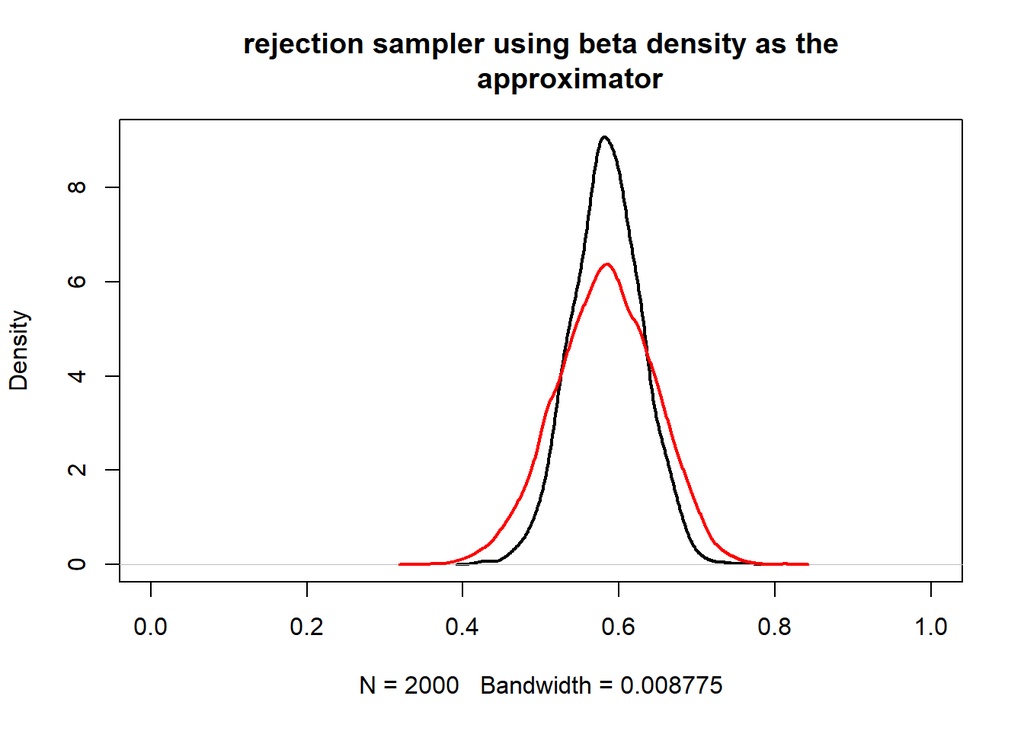

```r
##Superimpose density plot for beta approximation  densisty to
#illustrate good approximator
plot(density(storetheta2),main="rejection sampler using beta density as the
       approximator",
     xlim=c(0,1),lwd=2)
lines(density_pos_betaapprx,lwd=2,col="red")
```

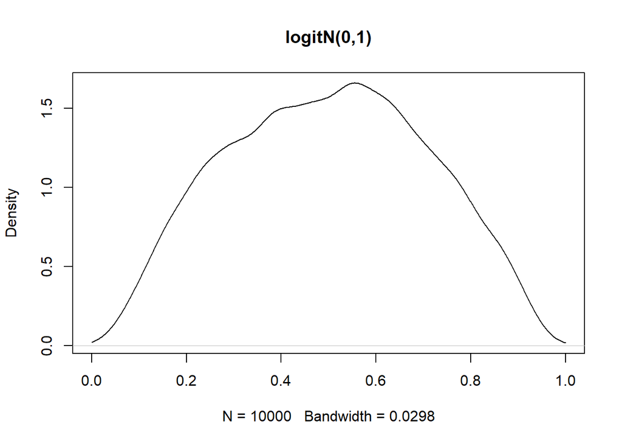

```r
mu_prior <- logit(0.5)
sigma_prior <- 1

##Re-draw the logit-normal  sample from the prior
testtheta <- rlogitnormal(n=10000,mu=mu_prior,sigma=sigma_prior)
density_prior <- density(testtheta)
plot(density(testtheta,from=0,to=1),main=paste("logitN(",round(mu_prior,2),",",sigma_prior,")",sep=""))
```

```r
summary(testtheta)
```

```
##    Min. 1st Qu.  Median    Mean 3rd Qu.    Max.
##  0.0191  0.3359  0.5030  0.4992  0.6590  0.9824
```

```r
###obtain a beta distribution with the same mean and variance as logit-normal sample
mean_theta <- mean(testtheta)
var_theta <- (sd(testtheta))^2
mean_theta
```

```
## [1] 0.4992291
```

```r
var_theta
```

```
## [1] 0.04363631
```

```r
a <- (mean_theta^2*(1-mean_theta) - var_theta*mean_theta)/var_theta
b <- a*(1-mean_theta)/mean_theta
a
```

```
## [1] 2.360934
```

```r
b
```

```
## [1] 2.368226
```

```r
###plot the beta density with these values
##could  do  exactly using dbeta but will simulate

apprxtheta <- rbeta(10000,a,b)
summary(apprxtheta)
```

```
##    Min. 1st Qu.  Median    Mean 3rd Qu.    Max.
## 0.01475 0.33750 0.49697 0.49981 0.66027 0.99415
```

```r
mean(apprxtheta)
```

```
## [1] 0.4998055
```

```r
(sd(apprxtheta))^2
```

```
## [1] 0.0441892
```

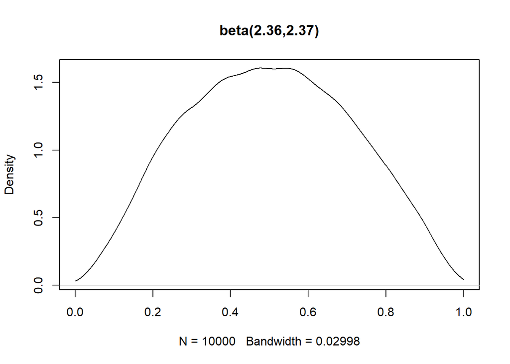

```r
density_prior_beta <- density(apprxtheta,from=0,to=1)
plot(density_prior_beta,main=paste("beta(",round(a,2),",",round(b,2),")",sep=""))
```

```r
###beta approximation to the posterior  --
#this will be the approximating density for the rejection sampler
## That is we are approximating the posterior with a distribution
## that could plausibly  have been the posterior had a conjugate prior
##prior been adopted.

apos <- a + sumY #sum_i Y_i
bpos <- b + sumNmY  #sum_i (N_i-Y_i)

#check approximate posterior mean
apos/(apos+bpos)
```

```
## [1] 0.5771886
```

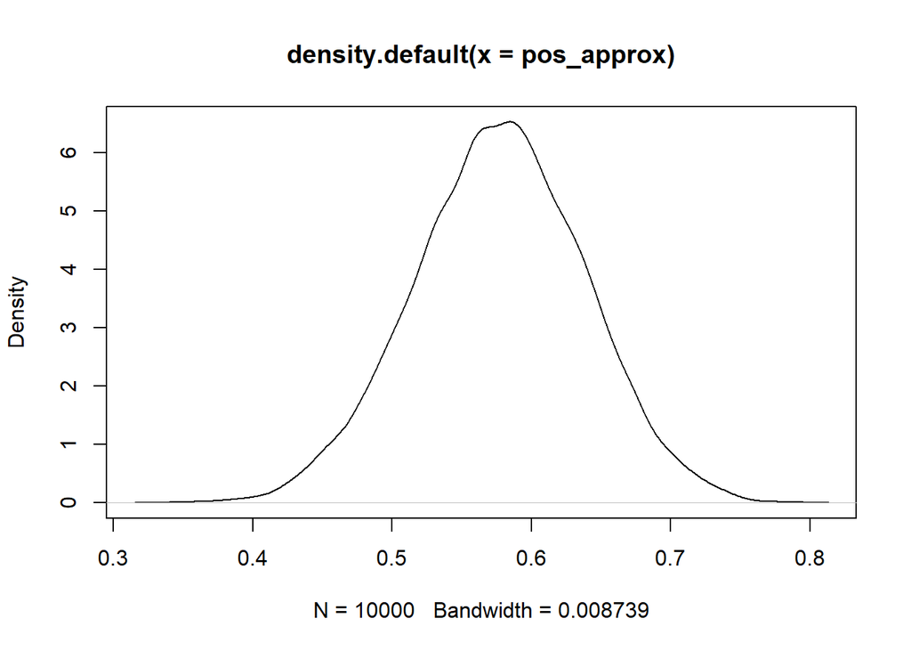

```r
pos_approx <- rbeta(10000,apos,bpos)
density_pos_betaapprx <- density(pos_approx)
plot(density(pos_approx))
```

```r
####Need to find max of
#Binomial(Y|N,\theta)logit(theta|mu,\sigma) / beta(\theta|apos,bpos);
# (on log scale)
##Function to compute logr
logr <- function(phi) {
  rtheta <- (sum(Y)*log(phi) + sum(N-Y)*log(1-phi) +
               dlogitnorm(q=phi,mu=mu_prior,s=sigma_prior,log=TRUE))
  - dbeta(phi,shape1=apos,shape2=bpos,log=TRUE)
  return(rtheta)}

#evaluate logr over the (0,1) interval

theta_test <- seq(from=0.001,to=0.999,by=0.0001)
logrtheta<- logr(phi=theta_test)
summary(logrtheta)
```

```
##    Min. 1st Qu.  Median    Mean 3rd Qu.    Max.
## -259.66  -66.91  -49.49  -60.18  -42.36  -40.31
```

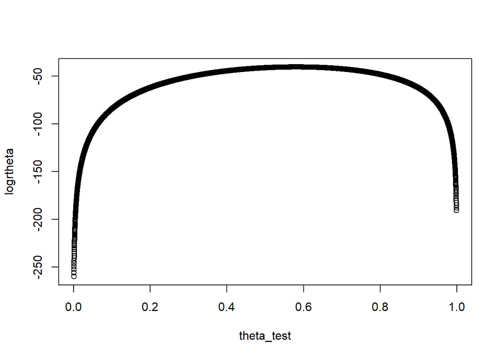

```r
plot(theta_test,logrtheta)
```

```r
which.max(logrtheta)  ###This identifies the position in the logrtheta vector
```

```
## [1] 5797
```

```r
###at which the maximum value of logrtheta is found

theta_maxr <- theta_test[which.max(logrtheta)]     #Value of theta which maximises logrtheta
logM2 <- logrtheta[which.max(logrtheta)]
theta_maxr
```

```
## [1] 0.5806
```

```r
logM2
```

```
## [1] -40.31172
```

```r
##check logM2 should equal the value of logr evaluated at theta_maxr
logr(theta_maxr)
```

```
## [1] -40.31172
```

Now, we know $\log M$ we can set up the rejection sampler.

```r
simnum <- 2000 #desired simulation sample size
storetheta3 <- vector(mode="numeric",length=simnum)
accepted3 <- 0
rejected3 <- 0

while(accepted3 < simnum) {
  theta_prop <- rbeta(n=1,shape=apos,shape2=bpos)
  ###Evaluate the log - importance ratio at this proposal
  logr_prop <- logr(phi=theta_prop)

  U <- runif(1)
  if (log(U) < logr_prop - logM2) {
    accepted3<- accepted3 + 1
    storetheta3[accepted3] <- theta_prop
  } else {
    rejected3 <- rejected3 + 1
  }
}
summary(storetheta3)
```

```
##    Min. 1st Qu.  Median    Mean 3rd Qu.    Max.
##  0.4442  0.5486  0.5798  0.5787  0.6088  0.7089
```

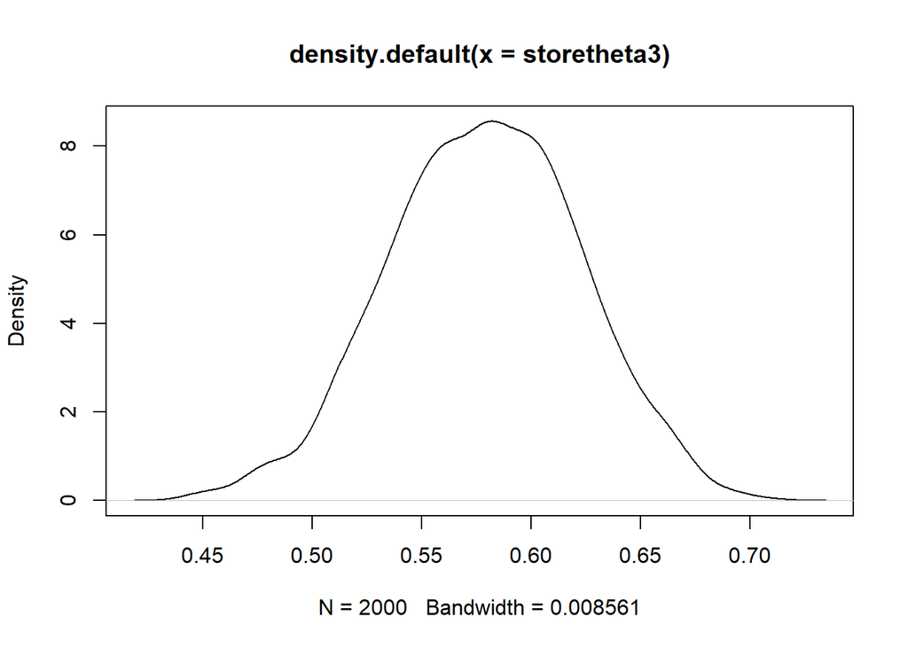

```r
plot(density(storetheta3))
```

```r
accepted3
```

```
## [1] 2000
```

```r
rejected3
```

```
## [1] 782
```

```r
acceptance_rate3 <- accepted3/(accepted3 + rejected3)
acceptance_rate3
```

```
## [1] 0.7189073
```

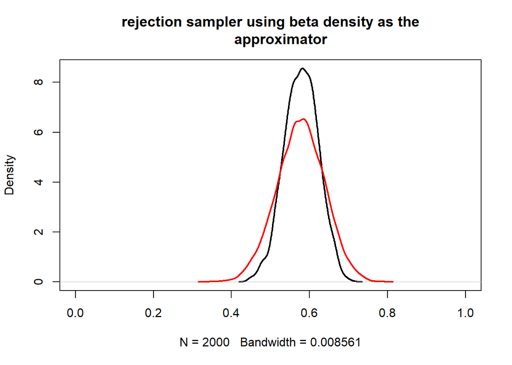

```r
##Superimpose density plot for beta approximation  densisty to
#illustrate good approximator
plot(density(storetheta3),main="rejection sampler using beta density as the
     approximator",
     xlim=c(0,1),lwd=2)
lines(density_pos_betaapprx,lwd=2,col="red")
```